# Assignment 9_wine data

2024-04-19

```r
# Load required libraries
library(cluster)     # For cluster analysis
library(readr)       # For reading data files
library(factoextra)  # For visualizing multivariate analysis results
library(magrittr)    # For using the pipe operator %>%
library(NbClust)     # For determining the optimal number of clusters
```

```r
#for loading csv data
library(readr)

# Read the CSV file
df <- read_csv("C:/Rutgers/Subjects/Spring Sem/Multivariate Analysis/Data/wine.csv")
#dataframe
df
```

```
## # A tibble: 1,599 × 12
##    `fixed acidity` `volatile acidity` `citric acid` `residual sugar` chlorides
##              <dbl>              <dbl>         <dbl>            <dbl>     <dbl>
##  1             7.4               0.7           0                 1.9     0.076
##  2             7.8               0.88          0                 2.6     0.098
##  3             7.8               0.76          0.04              2.3     0.092
##  4            11.2               0.28          0.56              1.9     0.075
##  5             7.4               0.7           0                 1.9     0.076
##  6             7.4               0.66          0                 1.8     0.075
##  7             7.9               0.6           0.06              1.6     0.069
##  8             7.3               0.65          0                 1.2     0.065
##  9             7.8               0.58          0.02              2       0.073
## 10             7.5               0.5           0.36              6.1     0.071
## # ℹ 1,589 more rows
## # ℹ 7 more variables: `free sulfur dioxide` <dbl>,
## #   `total sulfur dioxide` <dbl>, density <dbl>, pH <dbl>, sulphates <dbl>,
## #   alcohol <dbl>, quality <chr>
```

```r
attach(df)
xtabs(~ quality + alcohol, data = df)
```

```
##        alcohol
## quality 8.4 8.5 8.7 8.8  9 9.05 9.1 9.2 9.23333333333333 9.25 9.3 9.4 9.5 9.55
##    bad    1   1   0   2 14    1  16  53                0    0  46  81  97    1
##    good   1   0   2   0 16    0   7  19                1    1  13  22  42    1
##        alcohol
## quality 9.56666666666667 9.6 9.7 9.8 9.9 9.95 10 10.0333333333333 10.1 10.2
##    bad                 0  44  38  53  27    1 33                0   24   22
##    good                1  15  16  25  22    0 34                2   23   24
##        alcohol
## quality 10.3 10.4 10.5 10.55 10.6 10.7 10.75 10.8 10.9 11 11.0666666666667 11.1
##    bad    14   15   32     0    8    8     0    9   17 24                0    8
##    good   19   26   35     2   20   19     1   33   32 35                1   19
##        alcohol
## quality 11.2 11.3 11.4 11.5 11.6 11.7 11.8 11.9 11.95 12 12.1 12.2 12.3 12.4
##    bad    11    6   11    5    1    1    3    1     1  2    1    1    0    0
##    good   25   26   21   25   14   22   26   19     0 19   12   11   12   13
##        alcohol
## quality 12.5 12.6 12.7 12.8 12.9 13 13.1 13.2 13.3 13.4 13.5 13.5666666666667
##    bad     0    1    0    1    2  4    1    0    0    0    0                0
##    good   21    5    9   16    7  2    1    1    3    3    1                1
##        alcohol
## quality 13.6 14 14.9
##    bad     0  0    1
##    good    4  7    0
```

```r
xtabs(~ quality + `citric acid`, data = df)
```

```
##        citric acid
## quality  0 0.01 0.02 0.03 0.04 0.05 0.06 0.07 0.08 0.09 0.1 0.11 0.12 0.13 0.14
##    bad  70   12   20   20   19   13   12   11   17   15  21    9   12    9   14
##    good 62   21   30   10   10    7   12   11   16   15  14    6   15    9    7
##        citric acid
## quality 0.15 0.16 0.17 0.18 0.19 0.2 0.21 0.22 0.23 0.24 0.25 0.26 0.27 0.28
##    bad    11    4   11    9   13  17   22   16   17   25   18   28    8   10
##    good    8    5    5   13    8   8   11   11    8   26    9   10   12    9
##        citric acid
## quality 0.29 0.3 0.31 0.32 0.33 0.34 0.35 0.36 0.37 0.38 0.39 0.4 0.41 0.42
##    bad    14  12    9   14   11    6    6   11    6    5    9   8    5    7
##    good    7  18   21   18   14   18    7    9   13    9   19  21   11   22
##        citric acid
## quality 0.43 0.44 0.45 0.46 0.47 0.48 0.49 0.5 0.51 0.52 0.53 0.54 0.55 0.56
##    bad     5    9    5    2    3    8   35  10    3    7    1    5    4    1
##    good   10   14   17   17   15   15   33  10   10   10   13    8    8    7
##        citric acid
## quality 0.57 0.58 0.59 0.6 0.61 0.62 0.63 0.64 0.65 0.66 0.67 0.68 0.69 0.7
##    bad     3    4    4   5    2    0    3    2    5    3    0    3    0   2
##    good    6    5    4   4    0    1    7    7    2   11    2    8    4   0
##        citric acid
## quality 0.71 0.72 0.73 0.74 0.75 0.76 0.78 0.79  1
##    bad     0    0    0    1    0    1    0    1  1
##    good    1    1    3    3    1    2    1    0  0
```

```r
xtabs(~ quality + `fixed acidity`, data = df)
```

```
##        fixed acidity
## quality 4.6 4.7 4.9  5 5.1 5.2 5.3 5.4 5.5 5.6 5.7 5.8 5.9  6 6.1 6.2 6.3 6.4
##    bad    1   0   0  2   0   1   1   0   0  10   1   1   3  6  10  11   5  11
##    good   0   1   1  4   4   5   3   5   1   4   1   3   6  7   6   9   9  14
##        fixed acidity
## quality 6.5 6.6 6.7 6.8 6.9  7 7.1 7.2 7.3 7.4 7.5 7.6 7.7 7.8 7.9  8 8.1 8.2
##    bad    8  17  13  22  17 24  34  32  25  25  28  27  28  30  17 19  19  16
##    good   9  20  15  24  21 26  23  35  19  19  24  19  21  23  25 23   7  29
##        fixed acidity
## quality 8.3 8.4 8.5 8.6 8.7 8.8 8.9  9 9.1 9.2 9.3 9.4 9.5 9.6 9.7 9.8 9.9 10
##    bad   19  15   9  17  10  19  12 17   8  10  12   5   7   8   5   6  19  9
##    good  21  11  10  10  14  15  21  9  21   6  10  12   7   9   4   9   7 14
##        fixed acidity
## quality 10.1 10.2 10.3 10.4 10.5 10.6 10.7 10.8 10.9 11 11.1 11.2 11.3 11.4
##    bad     1    6    2    5    1    5    4    5    1  2    2    2    2    1
##    good    9   13    9   16   11    9    6    5    7  1    7    3    5    4
##        fixed acidity
## quality 11.5 11.6 11.7 11.8 11.9 12 12.1 12.2 12.3 12.4 12.5 12.6 12.7 12.8
##    bad     2    4    1    0    3  1    1    2    4    1    4    0    3    0
##    good   11    8    2    3    9  6    0    2    1    3    3    4    1    5
##        fixed acidity
## quality 12.9 13 13.2 13.3 13.4 13.5 13.7 13.8 14 14.3 15 15.5 15.6 15.9
##    bad     0  1    1    1    0    1    0    0  0    0  0    2    1    1
##    good    2  2    2    2    1    0    2    1  1    1  2    0    1    0
```

```r
xtabs(~ quality + `volatile acidity`, data=df)
```

```
##        volatile acidity
## quality 0.12 0.16 0.18 0.19 0.2 0.21 0.22 0.23 0.24 0.25 0.26 0.27 0.28 0.29
##    bad     0    0    2    1   1    1    0    2    2    0    2    1    5    3
##    good    3    2    8    1   2    5    6    3   11    7   14   13   18   13
##        volatile acidity
## quality 0.295 0.3 0.305 0.31 0.315 0.32 0.33 0.34 0.35 0.36 0.365 0.37 0.38
##    bad      0   0     0    4     0   10    4    9    7    5     2    9   11
##    good     1  16     2   26     2   13   16   21   15   33     0   15   24
##        volatile acidity
## quality 0.39 0.395 0.4 0.41 0.415 0.42 0.43 0.44 0.45 0.46 0.47 0.475 0.48 0.49
##    bad    16     0   9   16     1   12   23    7   12   17   10     0    9   16
##    good   19     2  28   17     2   19   20   16   10   14   11     2   15   19
##        volatile acidity
## quality 0.5 0.51 0.52 0.53 0.54 0.545 0.55 0.56 0.565 0.57 0.575 0.58 0.585
##    bad   25    2   15    8   15     0   11   21     1   12     3   18     1
##    good  21   22   18   21   16     5    9   13     0   16     0   20     2
##        volatile acidity
## quality 0.59 0.595 0.6 0.605 0.61 0.615 0.62 0.625 0.63 0.635 0.64 0.645 0.65
##    bad    22     1  31     1   18     4   16     2   16     4   19     6    8
##    good   17     0  16     2    9     2    8     1   13     5    8     6    8
##        volatile acidity
## quality 0.655 0.66 0.665 0.67 0.675 0.68 0.685 0.69 0.695 0.7 0.705 0.71 0.715
##    bad      7   16     3   13     3    9     7   14     6   6     5    2     7
##    good     0   10     0   10     0    3     4    9     1   4     1    1     5
##        volatile acidity
## quality 0.72 0.725 0.73 0.735 0.74 0.745 0.75 0.755 0.76 0.765 0.77 0.775 0.78
##    bad     4     6    6     5    5     3    3     2    2     3    3     3    8
##    good    1     3    0     3    6     2    3     1    3     2    3     1    2
##        volatile acidity
## quality 0.785 0.79 0.795 0.8 0.805 0.81 0.815 0.82 0.825 0.83 0.835 0.84 0.845
##    bad      4    1     1   2     1    1     2    5     0    3     3    2     1
##    good     4    1     1   1     0    1     1    0     1    1     1    6     0
##        volatile acidity
## quality 0.85 0.855 0.86 0.865 0.87 0.875 0.88 0.885 0.89 0.895 0.9 0.91 0.915
##    bad     1     0    1     0    4     2    5     5    1     0   2    2     3
##    good    1     3    1     1    0     0    0     0    0     1   1    1     1
##        volatile acidity
## quality 0.92 0.935 0.95 0.955 0.96 0.965 0.975 0.98  1 1.005 1.01 1.02 1.025
##    bad     1     2    1     1    2     3     1    2  1     1    0    3     1
##    good    0     0    0     0    1     0     0    1  2     0    1    1     0
##        volatile acidity
## quality 1.035 1.04 1.07 1.09 1.115 1.13 1.18 1.185 1.24 1.33 1.58
##    bad      1    2    1    1     1    1    1     1    1    2    1
##    good     0    1    0    0     0    0    0     0    0    0    0
```

```r
xtabs(~ quality + `residual sugar`, data=df)
```

```
##        residual sugar
## quality 0.9 1.2 1.3 1.4 1.5 1.6 1.65 1.7 1.75 1.8 1.9  2 2.05 2.1 2.15 2.2 2.25
##    bad    0   2   3  15  17  38    1  33    1  60  56 77    0  52    0  59    1
##    good   2   6   2  20  13  20    1  43    1  69  61 79    2  76    2  72    0
##        residual sugar
## quality 2.3 2.35 2.4 2.5 2.55 2.6 2.65 2.7 2.8 2.85 2.9 2.95  3 3.1 3.2 3.3 3.4
##    bad   54    1  26  37    1  42    0  18  19    1  12    0 13   3   4   6  12
##    good  55    0  60  47    0  37    1  21  30    0  12    1 12   4  11   5   3
##        residual sugar
## quality 3.45 3.5 3.6 3.65 3.7 3.75 3.8 3.9  4 4.1 4.2 4.25 4.3 4.4 4.5 4.6 4.65
##    bad     1   1   1    0   1    1   5   6  2   2   3    1   4   2   4   1    2
##    good    0   1   7    1   3    0   3   0  9   4   2    0   4   2   0   5    0
##        residual sugar
## quality 4.7 4.8  5 5.1 5.15 5.2 5.4 5.5 5.6 5.7 5.8 5.9  6 6.1 6.2 6.3 6.4 6.55
##    bad    0   2  0   1    1   0   1   4   4   1   1   2  1   4   0   1   2    0
##    good   1   1  1   4    0   3   0   4   2   0   3   1  3   0   3   1   1    2
##        residual sugar
## quality 6.6 6.7  7 7.2 7.3 7.5 7.8 7.9 8.1 8.3 8.6 8.8 8.9  9 10.7 11 12.9 13.4
##    bad    2   1  1   1   1   1   2   3   2   0   0   0   0  0    0  0    1    0
##    good   0   1  0   0   0   0   0   0   0   3   1   2   1  1    1  2    0    1
##        residual sugar
## quality 13.8 13.9 15.4 15.5
##    bad     2    0    0    1
##    good    0    1    2    0
```

```r
xtabs(~ quality + chlorides, data=df)
```

```
##        chlorides
## quality 0.012 0.034 0.038 0.039 0.041 0.042 0.043 0.044 0.045 0.046 0.047 0.048
##    bad      0     0     0     1     1     1     0     0     2     0     2     2
##    good     2     1     2     3     3     2     1     5     2     4     2     6
##        chlorides
## quality 0.049 0.05 0.051 0.052 0.053 0.054 0.055 0.056 0.057 0.058 0.059 0.06
##    bad      5    4     0     1     4     4     3     3     6     5     3    5
##    good     3    8     1     9     1     9     5     6     4     9    14   11
##        chlorides
## quality 0.061 0.062 0.063 0.064 0.065 0.066 0.067 0.068 0.069 0.07 0.071 0.072
##    bad      3     6     5     4     5     9    12     9     9   21    21     8
##    good     8    18    17    16    18    23    15    21    12   14    26    16
##        chlorides
## quality 0.073 0.074 0.075 0.076 0.077 0.078 0.079 0.08 0.081 0.082 0.083 0.084
##    bad     14    23    20    29    24    23    19   39    24    23    17    24
##    good    21    32    25    22    23    28    24   27    16    23    18    25
##        chlorides
## quality 0.085 0.086 0.087 0.088 0.089 0.09 0.091 0.092 0.093 0.094 0.095 0.096
##    bad      8    19    14    17    16   12     6     9     9     9    10    11
##    good    17    12    11    15     9    9    13    13    12    10    13     7
##        chlorides
## quality 0.097 0.098 0.099 0.1 0.101 0.102 0.103 0.104 0.105 0.106 0.107 0.108
##    bad      9     9     8   7     3     7     3     9     5     6     5     1
##    good     9     3     0   6     2     3     4     7     1     2     4     0
##        chlorides
## quality 0.109 0.11 0.111 0.112 0.113 0.114 0.115 0.116 0.117 0.118 0.119 0.12
##    bad      1    3     5     6     1     6     4     1     2     3     0    1
##    good     2    5     2     0     0     5     1     1     2     5     3    2
##        chlorides
## quality 0.121 0.122 0.123 0.124 0.125 0.126 0.127 0.128 0.132 0.136 0.137 0.143
##    bad      0     5     2     2     0     1     1     0     1     1     1     0
##    good     2     2     4     1     1     0     0     1     3     0     0     1
##        chlorides
## quality 0.145 0.146 0.147 0.148 0.152 0.153 0.157 0.159 0.161 0.165 0.166 0.168
##    bad      1     1     1     0     2     0     1     1     1     1     3     1
##    good     0     0     0     1     0     1     2     0     0     0     0     0
##        chlorides
## quality 0.169 0.17 0.171 0.172 0.174 0.176 0.178 0.186 0.19 0.194 0.2 0.205
##    bad      1    1     0     1     0     1     1     1    0     0   1     2
##    good     0    0     2     0     1     0     1     0    1     1   0     0
##        chlorides
## quality 0.213 0.214 0.216 0.222 0.226 0.23 0.235 0.236 0.241 0.243 0.25 0.263
##    bad      0     0     0     0     0    0     1     1     0     0    0     1
##    good     1     3     1     1     2    1     0     0     1     1    1     0
##        chlorides
## quality 0.267 0.27 0.332 0.337 0.341 0.343 0.358 0.36 0.368 0.369 0.387 0.401
##    bad      1    1     0     0     0     1     0    1     1     1     1     1
##    good     0    0     1     1     1     0     1    0     0     0     0     0
##        chlorides
## quality 0.403 0.413 0.414 0.415 0.422 0.464 0.467 0.61 0.611
##    bad      1     0     1     2     1     1     1    1     1
##    good     0     1     1     1     0     0     0    0     0
```

```r
xtabs(~ quality + `free sulfur dioxide`, data=df)
```

```
##        free sulfur dioxide
## quality  1  2  3  4  5 5.5  6  7  8  9 10 11 12 13 14 15 16 17 18 19 20 21 22
##    bad   0  0 20 23 54   0 44 33 24 32 40 25 40 21 19 39 30 24 18 16 17 23  8
##    good  3  1 29 18 50   1 94 38 32 30 39 34 35 36 31 39 31 36 28 23 13 18 14
##        free sulfur dioxide
## quality 23 24 25 26 27 28 29 30 31 32 33 34 35 36 37 37.5 38 39 40 40.5 41 42
##    bad  16 13 14 13 16 15  9  9 10 13  5 12 10  7  2    0  3  3  3    0  2  1
##    good 16 21 10 19 13  8 14  7 10  9  6  6  5  4  1    2  6  2  3    1  5  2
##        free sulfur dioxide
## quality 43 45 46 47 48 50 51 52 53 54 55 57 66 68 72
##    bad   2  1  1  1  3  1  3  2  0  0  0  1  1  2  0
##    good  1  2  0  0  1  1  1  1  1  1  2  0  0  0  1
```

```r
xtabs(~ quality + `total sulfur dioxide`, data=df)
```

```
##        total sulfur dioxide
## quality  6  7  8  9 10 11 12 13 14 15 16 17 18 19 20 21 22 23 24 25 26 27 28 29
##    bad   2  2  5  5  4 12 16 16 14 13  9  7 13 12 17  6 14 19  5  8 13  9 13  7
##    good  1  2  9  9 23 14 13 12 19 22 17 20 22 17 16 19 11 15 31 19 11 21 30 13
##        total sulfur dioxide
## quality 30 31 32 33 34 35 36 37 38 39 40 41 42 43 44 45 46 47 48 49 50 51 52 53
##    bad   4 15 12  6  7  7  5 13 13  6 10  3 12  4  6 10  4 10  9 10  3  5  8  6
##    good 10 17  8 11 13 19  7 13 18 10  7 11 14 14 17 10 13 14 12 11  8  6  7  8
##        total sulfur dioxide
## quality 54 55 56 57 58 59 60 61 62 63 64 65 66 67 68 69 70 71 72 73 74 75 76 77
##    bad   9  6  4  3  7  4  9  5  3  7  4 10  7  8  7  2  3  6  8  4  1  4  1  4
##    good 11  7  6  3  7  5  9  4  6  6  6  7  2  4  3  6  5  1  2  3  7  1  2  4
##        total sulfur dioxide
## quality 77.5 78 79 80 81 82 83 84 85 86 87 88 89 90 91 92 93 94 95 96 98 99 100
##    bad     2  3  1  1  1  3  1  6  8  6  4  8  4  5  2  5  1  4  2  5  4  5   1
##    good    0  1  4  3  5  1  1  0  1  4  2  6  5  0  5  3  1  4  2  0  3  1   2
##        total sulfur dioxide
## quality 101 102 103 104 105 106 108 109 110 111 112 113 114 115 116 119 120 121
##    bad    3   5   0   5   3   4   3   1   6   3   3   4   1   2   1   7   2   4
##    good   1   1   2   0   2   2   0   3   0   0   0   0   1   0   0   0   0   0
##        total sulfur dioxide
## quality 122 124 125 126 127 128 129 130 131 133 134 135 136 139 140 141 142 143
##    bad    3   3   2   1   2   2   3   1   3   3   2   2   0   1   1   3   1   2
##    good   0   0   0   0   0   0   0   0   0   0   0   0   2   0   0   0   0   0
##        total sulfur dioxide
## quality 144 145 147 148 149 151 152 153 155 160 165 278 289
##    bad    3   3   3   1   0   2   1   1   1   0   0   0   0
##    good   0   0   0   1   1   0   0   0   0   1   1   1   1
```

```r
xtabs(~ quality + density, data=df)
```

```
##        density
## quality 0.99007 0.9902 0.99064 0.9908 0.99084 0.9912 0.9915 0.99154 0.99157
##    bad        0      0       0      0       0      0      0       0       0
##    good       2      1       2      1       1      1      1       1       1
##        density
## quality 0.9916 0.99162 0.9917 0.99182 0.99191 0.9921 0.9922 0.99235 0.99236
##    bad       0       0      0       0       0      0      0       0       0
##    good      2       1      1       2       1      1      2       1       1
##        density
## quality 0.9924 0.99242 0.99252 0.99256 0.99258 0.99264 0.9927 0.9928 0.99286
##    bad       0       0       0       1       1       0      0      0       1
##    good      3       2       1       0       2       1      1      2       0
##        density
## quality 0.9929 0.99292 0.99294 0.99306 0.99314 0.99316 0.99318 0.9932 0.99322
##    bad       0       0       0       1       0       0       0      0       1
##    good      1       1       2       0       1       2       1      1       0
##        density
## quality 0.99323 0.99328 0.9933 0.99331 0.99332 0.99334 0.99336 0.9934 0.99341
##    bad        0       0      0       0       0       1       1      2       1
##    good       1       1      1       2       1       0       0      2       0
##        density
## quality 0.99344 0.99346 0.99348 0.9935 0.99352 0.99354 0.99356 0.99357 0.99358
##    bad        0       1       1      0       0       0       0       0       1
##    good       1       2       0      1       2       2       4       1       2
##        density
## quality 0.9936 0.99362 0.99364 0.9937 0.99371 0.99374 0.99376 0.99378 0.99379
##    bad       0       1       0      2       0       1       0       1       0
##    good      2       1       1      0       2       1       3       2       1
##        density
## quality 0.9938 0.99384 0.99385 0.99386 0.99387 0.99388 0.99392 0.99394 0.99395
##    bad       1       0       1       0       0       0       1       0       1
##    good      0       1       0       1       1       2       1       1       0
##        density
## quality 0.99396 0.99397 0.994 0.99402 0.99408 0.9941 0.99414 0.99416 0.99417
##    bad        1       0     1       2       0      1       0       0       0
##    good       2       1     1       2       3      0       2       1       1
##        density
## quality 0.99418 0.99419 0.9942 0.99425 0.99426 0.99428 0.9943 0.99434 0.99437
##    bad        0       0      3       1       0       0      1       0       1
##    good       2       2      0       0       1       1      1       1       0
```

[output cut: 141 more lines]

```
## quality 0.99965 0.9997 0.99974 0.99975 0.99976 0.9998 0.9999  1 1.00005 1.0001
##    bad        0      5       0       1       1      6      1  3       0      4
##    good       1      3       1       0       0      4      0  7       2      0
##        density
## quality 1.00012 1.00015 1.0002 1.00024 1.00025 1.0003 1.0004 1.0006 1.0008
##    bad        0       2      2       1       1      0      7      3      1
##    good       1       0      8       0       0      2      2      3      2
##        density
## quality 1.001 1.0014 1.0015 1.0018 1.0021 1.0022 1.00242 1.0026 1.00289 1.00315
##    bad      4      1      0      1      0      0       2      1       1       3
##    good     2      5      2      0      2      2       0      1       0       0
##        density
## quality 1.0032 1.00369
##    bad       0       0
##    good      1       2
```

```r
xtabs(~ quality + pH, data=df)
```

```
##        pH
## quality 2.74 2.86 2.87 2.88 2.89 2.9 2.92 2.93 2.94 2.95 2.98 2.99  3 3.01 3.02
##    bad     1    0    0    1    2   0    3    1    2    0    2    2  4    1    3
##    good    0    1    1    1    2   1    1    2    2    1    3    0  2    4    5
##        pH
## quality 3.03 3.04 3.05 3.06 3.07 3.08 3.09 3.1 3.11 3.12 3.13 3.14 3.15 3.16
##    bad     4    5    5    3    1    7    5  10    3    6   10   12   17   21
##    good    2    5    3    7   10    4    6   9    6   14    3    9   17   15
##        pH
## quality 3.17 3.18 3.19 3.2 3.21 3.22 3.23 3.24 3.25 3.26 3.27 3.28 3.29 3.3
##    bad    12   11   15  20   11   13   13   14   17   26   12   25   24  26
##    good   15   19   10  19   25   26   19   15    9   27   23   17   22  31
##        pH
## quality 3.31 3.32 3.33 3.34 3.35 3.36 3.37 3.38 3.39 3.4 3.41 3.42 3.43 3.44
##    bad    16   14   13   23   16   32   15   19   26  15   15   10    7   15
##    good   23   31   24   20   23   24   22   29   22  22   19   23   10   14
##        pH
## quality 3.45 3.46 3.47 3.48 3.49 3.5 3.51 3.52 3.53 3.54 3.55 3.56 3.57 3.58
##    bad     9   15    4   13    7   8    9    7   10    8    4    4    5    4
##    good   11    7   17    6    3   6    6   11    7    8    4    7    5    6
##        pH
## quality 3.59 3.6 3.61 3.62 3.63 3.66 3.67 3.68 3.69 3.7 3.71 3.72 3.74 3.75
##    bad     5   3    3    3    3    3    2    2    2   0    0    2    1    1
##    good    3   4    5    1    0    1    1    3    2   1    4    1    0    0
##        pH
## quality 3.78 3.85 3.9 4.01
##    bad     0    0   1    0
##    good    2    1   1    2
```

```r
xtabs(~ quality + sulphates, data=df)
```

```
##        sulphates
## quality 0.33 0.37 0.39 0.4 0.42 0.43 0.44 0.45 0.46 0.47 0.48 0.49 0.5 0.51
##    bad     1    2    4   2    4    6   13   12   14   15   21   23  21   18
##    good    0    0    2   2    1    2    3    0    4    4    8    8   6    8
##        sulphates
## quality 0.52 0.53 0.54 0.55 0.56 0.57 0.58 0.59 0.6 0.61 0.62 0.63 0.64 0.65
##    bad    36   34   41   30   30   36   38   21  24   27   31   21   22   12
##    good   11   17   27   20   30   19   30   30  45   18   30   27   24   29
##        sulphates
## quality 0.66 0.67 0.68 0.69 0.7 0.71 0.72 0.73 0.74 0.75 0.76 0.77 0.78 0.79
##    bad    15   16   13    5   8   11    8    8    8    4    1    5    9    5
##    good   27   20   22   18  25   15   20   18   18   16   24   21   14   13
##        sulphates
## quality 0.8 0.81 0.82 0.83 0.84 0.85 0.86 0.87 0.88 0.89 0.9 0.91 0.92 0.93
##    bad    7    1    3    3    2    0    3    2    2    0   1    3    0    4
##    good  12   14   19   12   11   14   10   11    5    7   7    5    5    6
##        sulphates
## quality 0.94 0.95 0.96 0.97 0.98 0.99  1 1.01 1.02 1.03 1.04 1.05 1.06 1.07
##    bad     1    1    0    2    1    1  0    0    1    1    0    2    1    2
##    good    3    1    3    4    1    2  1    1    2    1    2    1    3    0
##        sulphates
## quality 1.08 1.09 1.1 1.11 1.12 1.13 1.14 1.15 1.16 1.17 1.18 1.2 1.22 1.26
##    bad     1    1   1    0    1    0    2    1    0    5    1   1    1    1
##    good    2    0   1    1    0    2    0    0    1    0    2   0    0    0
##        sulphates
## quality 1.28 1.31 1.33 1.34 1.36 1.56 1.59 1.61 1.62 1.95 1.98  2
##    bad     2    1    0    1    0    1    1    0    1    0    1  1
##    good    0    0    1    0    3    0    0    1    0    2    0  0
```

```r
# Assuming 'quality' is a column in the data frame 'df'
distinct_values <- unique(df$quality)

# Print distinct values
print(distinct_values)
```

```
## [1] "bad"  "good"
```

```r
# Count the number of unique values
num_unique <- length(distinct_values)

# Print the number of unique values
print(num_unique)
```

```
## [1] 2
```

```r
table(df$quality)
```

```
##
##  bad good
##  744  855
```

```r
# Recode the quality variable to binary (0 for "bad" and 1 for "good")
#df$quality <- as.numeric(df$quality == "good")
df
```

```
## # A tibble: 1,599 × 12
##    `fixed acidity` `volatile acidity` `citric acid` `residual sugar` chlorides
##              <dbl>              <dbl>         <dbl>            <dbl>     <dbl>
##  1             7.4               0.7           0                 1.9     0.076
##  2             7.8               0.88          0                 2.6     0.098
##  3             7.8               0.76          0.04              2.3     0.092
##  4            11.2               0.28          0.56              1.9     0.075
##  5             7.4               0.7           0                 1.9     0.076
##  6             7.4               0.66          0                 1.8     0.075
##  7             7.9               0.6           0.06              1.6     0.069
##  8             7.3               0.65          0                 1.2     0.065
##  9             7.8               0.58          0.02              2       0.073
## 10             7.5               0.5           0.36              6.1     0.071
## # ℹ 1,589 more rows
## # ℹ 7 more variables: `free sulfur dioxide` <dbl>,
## #   `total sulfur dioxide` <dbl>, density <dbl>, pH <dbl>, sulphates <dbl>,
## #   alcohol <dbl>, quality <chr>
```

1. Model Development (2 points)

Alcohol:

Estimate: 1.00468

This indicates that for every one-unit increase in alcohol, the log-odds of the wine being of good quality (as opposed to bad quality) increase by 1.00468.

Std. Error: 0.06884 This shows the standard error associated with the coefficient estimate.

z value: 14.594

The z value is the coefficient estimate divided by its standard error. It indicates the number of standard deviations a parameter estimate is from the null hypothesis value of 0. The higher the z value, the more significant the predictor.

p-value: <0.0000000000000002 ***

The p-value indicates the significance of each predictor. In this case, the p-value is extremely low, indicating a significant relationship between alcohol and the quality of the wine.

Volatile Acidity:

Estimate: -3.54124

This indicates that for every one-unit increase in volatile acidity, the log-odds of the wine being of good quality (as opposed to bad quality) decrease by 3.54124.

Std. Error: 0.35470 This shows the standard error associated with the coefficient estimate.

z value: -9.984

The z value is the coefficient estimate divided by its standard error. It indicates the number of standard deviations a parameter estimate is from the null hypothesis value of 0. The more negative the z value, the more significant the negative relationship.

p-value: <0.0000000000000002 ***

The p-value indicates the significance of each predictor. In this case, the p-value is extremely low, indicating a significant relationship between volatile acidity and the quality of the wine.

```r
attach(df)
#df <- df[, !names(df) %in% "quality_new"]
# Fit logistic regression model with the binary indicator
# Fit logistic regression model with binary indicator

# Convert 'quality' variable to a factor
df$quality <- factor(df$quality, levels = c("bad", "good"))


logistic_simple <- glm(quality ~ alcohol + `volatile acidity`  , data = df, family = "binomial")

# Summary of the model
summary(logistic_simple)
```

```
##
## Call:
## glm(formula = quality ~ alcohol + `volatile acidity`, family = "binomial",
##     data = df)
##
## Coefficients:
##                    Estimate Std. Error z value Pr(>|z|)
## (Intercept)        -8.34395    0.72630 -11.488   <2e-16 ***
## alcohol             1.00468    0.06884  14.594   <2e-16 ***
## `volatile acidity` -3.54124    0.35470  -9.984   <2e-16 ***
## ---
## Signif. codes:  0 '***' 0.001 '**' 0.01 '*' 0.05 '.' 0.1 ' ' 1
##
## (Dispersion parameter for binomial family taken to be 1)
##
##     Null deviance: 2209.0  on 1598  degrees of freedom
## Residual deviance: 1752.5  on 1596  degrees of freedom
## AIC: 1758.5
##
## Number of Fisher Scoring iterations: 4
```

```r
df
```

```
## # A tibble: 1,599 × 12
##    `fixed acidity` `volatile acidity` `citric acid` `residual sugar` chlorides
##              <dbl>              <dbl>         <dbl>            <dbl>     <dbl>
##  1             7.4               0.7           0                 1.9     0.076
##  2             7.8               0.88          0                 2.6     0.098
##  3             7.8               0.76          0.04              2.3     0.092
##  4            11.2               0.28          0.56              1.9     0.075
##  5             7.4               0.7           0                 1.9     0.076
##  6             7.4               0.66          0                 1.8     0.075
##  7             7.9               0.6           0.06              1.6     0.069
##  8             7.3               0.65          0                 1.2     0.065
##  9             7.8               0.58          0.02              2       0.073
## 10             7.5               0.5           0.36              6.1     0.071
## # ℹ 1,589 more rows
## # ℹ 7 more variables: `free sulfur dioxide` <dbl>,
## #   `total sulfur dioxide` <dbl>, density <dbl>, pH <dbl>, sulphates <dbl>,
## #   alcohol <dbl>, quality <fct>
```

```r
predicted.data <- data.frame(probability.of.quality=logistic_simple$fitted.values,quality=df$quality)


options(scipen = 999)
predicted.data
```

```
##      probability.of.quality quality
## 1                0.20120458     bad
## 2                0.16598807     bad
## 3                0.23336924     bad
## 4                0.62490271    good
## 5                0.20120458     bad
## 6                0.22493539     bad
## 7                0.26412089     bad
## 8                0.35459301    good
## 9                0.29872728    good
## 10               0.60697565     bad
## 11               0.23961872     bad
## 12               0.60697565     bad
## 13               0.35998355     bad
## 14               0.20400044     bad
```

[output cut: 1585 more lines]

2. Model Acceptance (2 points)

Inference:

Volatile Acidity: As the volatile acidity level increases, the probability of wine quality being bad increases and the probability of wine quality being good decreases.

Interpretation:

At a volatile acidity level of 0.16:

At a volatile acidity level of 0.19:

```r
xtabs(~ probability.of.quality + `volatile acidity` + `citric acid`, data=predicted.data)
```

[output not shown]

[output cut: 9763 more lines]

[output not shown]

3. Residual Analysis (2 points)

Null Deviance (2209.0):

Represents the deviance when the model only consists of the intercept.

The higher the value, the worse the model fits the data without any predictors.

Residual Deviance (1804.7):

Represents the deviance when the predictors are included in the model.

The lower the value, the better the model fits the data with predictors.

Degrees of Freedom (1598 for Null, 1596 for Residuals):

Degrees of freedom are a measure of the amount of information that went into estimation of the parameters.

It’s the number of independent values or quantities that can be assigned to a statistical distribution.

Difference (404.3):

A measure of how much better the model with predictors explains the data compared to a model with just the intercept.

A larger difference implies a better fit of the model.

```r
logistic <- glm(quality ~ alcohol +  sulphates, data=df, family="binomial")
summary(logistic)
```

```
##
## Call:
## glm(formula = quality ~ alcohol + sulphates, family = "binomial",
##     data = df)
##
## Coefficients:
##              Estimate Std. Error z value             Pr(>|z|)
## (Intercept) -12.32438    0.73149 -16.848 < 0.0000000000000002 ***
## alcohol       1.03724    0.06728  15.417 < 0.0000000000000002 ***
## sulphates     2.67209    0.37097   7.203    0.000000000000589 ***
## ---
## Signif. codes:  0 '***' 0.001 '**' 0.01 '*' 0.05 '.' 0.1 ' ' 1
##
## (Dispersion parameter for binomial family taken to be 1)
##
##     Null deviance: 2209.0  on 1598  degrees of freedom
## Residual deviance: 1804.7  on 1596  degrees of freedom
## AIC: 1810.7
##
## Number of Fisher Scoring iterations: 4
```

```r
## Now calculate the overall "Pseudo R-squared" and its p-value
ll.null <- logistic$null.deviance/-2
ll.proposed <- logistic$deviance/-2
(ll.null - ll.proposed) / ll.null
```

```
## [1] 0.1830352
```

Predicted value = bad

```r
## The p-value for the R^2
1 - pchisq(2*(ll.proposed - ll.null), df=(length(logistic$coefficients)-1))
```

```
## [1] 0
```

```r
predicted.data$quality <-
data.frame(probability.of.quality=logistic$fitted.values,quality=df$quality)
```

4. Prediction (2 points)

Inference:

Low Predicted Probability of Bad Quality:

High Predicted Probability of Bad Quality:

Good Quality:

For instance, a value of 0.3521585 indicates a probability of being good quality, but there is still a possibility of it being bad quality.

probability:

probability.of.quality: The predicted probabilities of each quality category (bad or good).

quality: bad: Indicates low quality. good: Indicates high quality.

```r
data.frame(probability.of.quality=logistic$fitted.values,quality=df$quality)
```

```
##      probability.of.quality quality
## 1                 0.2539028     bad
## 2                 0.4152374     bad
## 3                 0.3959143     bad
## 4                 0.3521585    good
## 5                 0.2539028     bad
## 6                 0.2539028     bad
## 7                 0.2066703     bad
## 8                 0.3326894    good
## 9                 0.2793961    good
## 10                0.6691553     bad
## 11                0.2077082     bad
## 12                0.6691553     bad
## 13                0.3393559     bad
## 14                0.7829626     bad
```

[output cut: 1585 more lines]

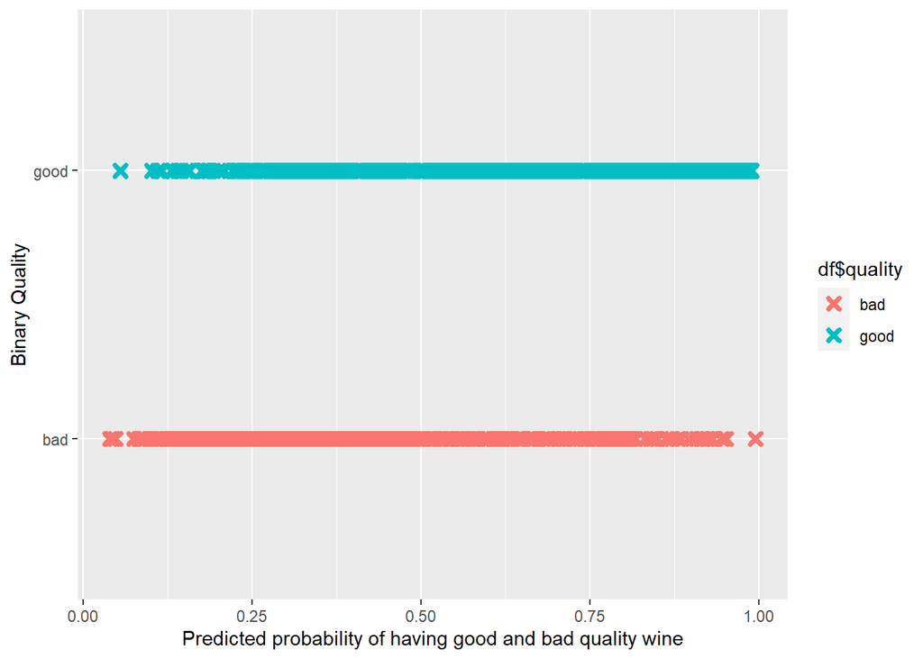

```r
ggplot(data = predicted.data, aes(x = probability.of.quality, y = df$quality)) +
  geom_point(aes(color = df$quality), alpha = 1, shape = 4, stroke = 2) +
  xlab("Predicted probability of having good and bad quality wine") +
  ylab("Binary Quality")
```

```r
# From Caret
pdata <- predict(logistic,newdata=df,type="response" )
pdata
```

```
##         1         2         3         4         5         6         7         8
## 0.2539028 0.4152374 0.3959143 0.3521585 0.2539028 0.2539028 0.2066703 0.3326894
##         9        10        11        12        13        14        15        16
## 0.2793961 0.6691553 0.2077082 0.6691553 0.3393559 0.7829626 0.3940586 0.4263695
##        17        18        19        20        21        22        23        24
## 0.6389391 0.6774938 0.1606866 0.5260103 0.2390186 0.3713936 0.4902644 0.2390186
##        25        26        27        28        29        30        31        32
## 0.3590052 0.2347594 0.2902815 0.4902644 0.2488742 0.3582785 0.4000456 0.5482271
##        33        34        35        36        37        38        39        40
## 0.4023225 0.2341923 0.2121399 0.2896311 0.6180127 0.4225107 0.2938467 0.6866556
##        41        42        43        44        45        46        47        48
## 0.6866556 0.2116124 0.7254336 0.8271777 0.2533047 0.9404701 0.3034130 0.2848075
##        49        50        51        52        53        54        55        56
## 0.2166403 0.2258470 0.3090901 0.2909328 0.2964757 0.2539028 0.4847392 0.2583920
##        57        58        59        60        61        62        63        64
## 0.3355008 0.3736090 0.4072381 0.2439127 0.2551016 0.3141443 0.3070697 0.3460866
##        65        66        67        68        69        70        71        72
## 0.5059264 0.5059264 0.3063979 0.5802879 0.7078769 0.7512296 0.2635454 0.2336262
##        73        74        75        76        77        78        79        80
## 0.2336262 0.2033452 0.4561848 0.5818260 0.5818260 0.5606481 0.3872902 0.5267979
##        81        82        83        84        85        86        87        88
## 0.2166403 0.6997279 0.2038575 0.6158356 0.6090870 0.4324970 0.9591024 0.3414840
##        89        90        91        92        93        94        95        96
## 0.6877028 0.1717941 0.2635454 0.9591024 0.9581682 0.3414840 0.4623954 0.9345841
##        97        98        99       100       101       102       103       104
## 0.5672190 0.2500573 0.3400645 0.1958180 0.4714052 0.4898364 0.1958180 0.1948250
##       105       106       107       108       109       110       111       112
## 0.2155699 0.1948250 0.6947542 0.3619184 0.4429611 0.3027457 0.5036235 0.4023225
##       113       114       115       116       117       118       119       120
## 0.4023225 0.3839535 0.5036235 0.5622038 0.4201998 0.2247442 0.6421817 0.2077082
##       121       122       123       124       125       126       127       128
## 0.1875389 0.6421817 0.1990508 0.2583920 0.2336262 0.3309677 0.5722203 0.5656672
##       129       130       131       132       133       134       135       136
## 0.7359489 0.2589979 0.3077424 0.9449673 0.9449673 0.3521585 0.3575524 0.4561848
##       137       138       139       140       141       142       143       144
## 0.3981833 0.2551016 0.2635454 0.2635454 0.4561848 0.3981833 0.9867184 0.2641590
##       145       146       147       148       149       150       151       152
## 0.9867184 0.2854515 0.3629827 0.3681116 0.4514864 0.5490094 0.4440979 0.9410280
##       153       154       155       156       157       158       159       160
## 0.4000456 0.4000456 0.6202476 0.6139339 0.6202476 0.6139339 0.2071888 0.2395937
```

[output cut: 345 more lines]

```
## 0.5439530 0.4914155 0.8588751 0.5071441 0.8007646 0.7334859 0.5799031 0.4965153
##      1545      1546      1547      1548      1549      1550      1551      1552
## 0.8110978 0.4655383 0.4714052 0.8304826 0.5031954 0.7974896 0.2583920 0.2439127
##      1553      1554      1555      1556      1557      1558      1559      1560
## 0.7613454 0.2746771 0.6656489 0.6072049 0.3637135 0.6656489 0.2740481 0.3393559
##      1561      1562      1563      1564      1565      1566      1567      1568
## 0.3393559 0.3393559 0.4000456 0.4000456 0.4000456 0.7636339 0.7667321 0.4000456
##      1569      1570      1571      1572      1573      1574      1575      1576
## 0.2305531 0.7552904 0.9535805 0.7162427 0.2482841 0.9191968 0.4623954 0.8355179
##      1577      1578      1579      1580      1581      1582      1583      1584
## 0.7235418 0.8350833 0.7661666 0.7310082 0.8350833 0.7310082 0.7949265 0.3769108
##      1585      1586      1587      1588      1589      1590      1591      1592
## 0.8635786 0.8639503 0.8546431 0.6781257 0.9541999 0.2077082 0.8697532 0.7692416
##      1593      1594      1595      1596      1597      1598      1599
## 0.7482658 0.4305921 0.5290937 0.7897725 0.7482658 0.5381023 0.7003355
```

```r
library(caret)
library(pROC)
pdataF <- as.factor(ifelse(test=as.numeric(pdata>0.5) == 0, yes="good", no="bad"))


attributes(pdataF)
```

```
## $levels
## [1] "bad"  "good"
##
## $class
## [1] "factor"
```

5. Model Accuracy (2 points)

Percentage of correctly predicted observations.

The confidence interval for the accuracy.

No Information Rate (NIR): 0.5347

The accuracy that could be achieved by always predicting the majority class.

P-Value [Acc > NIR]: 1.00000

The probability that the accuracy is greater than the No Information Rate.

A measure of how closely the instances classified as the same class agree with the actual classification.

A kappa of 1 represents perfect agreement, and a kappa of 0 represents agreement equivalent to random chance.

Negative values suggest no agreement.

A statistical test used on paired nominal data.

Tests if the row and column marginal frequencies are equal.

The proportion of actual positive cases that were correctly identified.

Specificity (True Negative Rate): 0.3064

The proportion of actual negative cases that were correctly identified.

The proportion of negative identifications that were actually correct.

Prevalence: 0.4653

The proportion of actual positive cases.

The proportion of actual positive cases

```r
# Create confusion matrix
confusionMatrix(pdataF, df$quality)
```

```
## Confusion Matrix and Statistics
##
##           Reference
## Prediction bad good
##       bad  220  593
##       good 524  262
##
##                Accuracy : 0.3014
##                  95% CI : (0.279, 0.3246)
##     No Information Rate : 0.5347
##     P-Value [Acc > NIR] : 1.00000
##
##                   Kappa : -0.3955
##
##  Mcnemar's Test P-Value : 0.04189
##
##             Sensitivity : 0.2957
##             Specificity : 0.3064
##          Pos Pred Value : 0.2706
##          Neg Pred Value : 0.3333
##              Prevalence : 0.4653
##          Detection Rate : 0.1376
##    Detection Prevalence : 0.5084
##       Balanced Accuracy : 0.3011
##
##        'Positive' Class : bad
##
```

```r
# From pROC
roc(df$quality,logistic$fitted.values,plot=TRUE)
```

```
##
## Call:
## roc.default(response = df$quality, predictor = logistic$fitted.values,     plot = TRUE)
##
## Data: logistic$fitted.values in 744 controls (df$quality bad) < 855 cases (df$quality good).
## Area under the curve: 0.7792
```

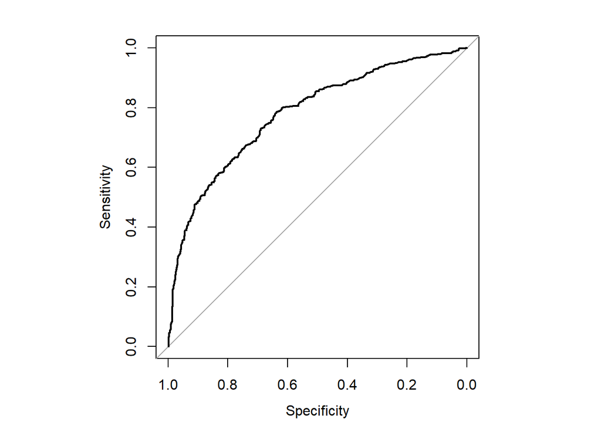

```
##
## Call:
## roc.default(response = df$quality, predictor = logistic$fitted.values,     plot = TRUE)
##
## Data: logistic$fitted.values in 744 controls (df$quality bad) < 855 cases (df$quality good).
## Area under the curve: 0.7792
```

```r
par(pty = "s")
roc(df$quality,logistic$fitted.values,plot=TRUE)
```

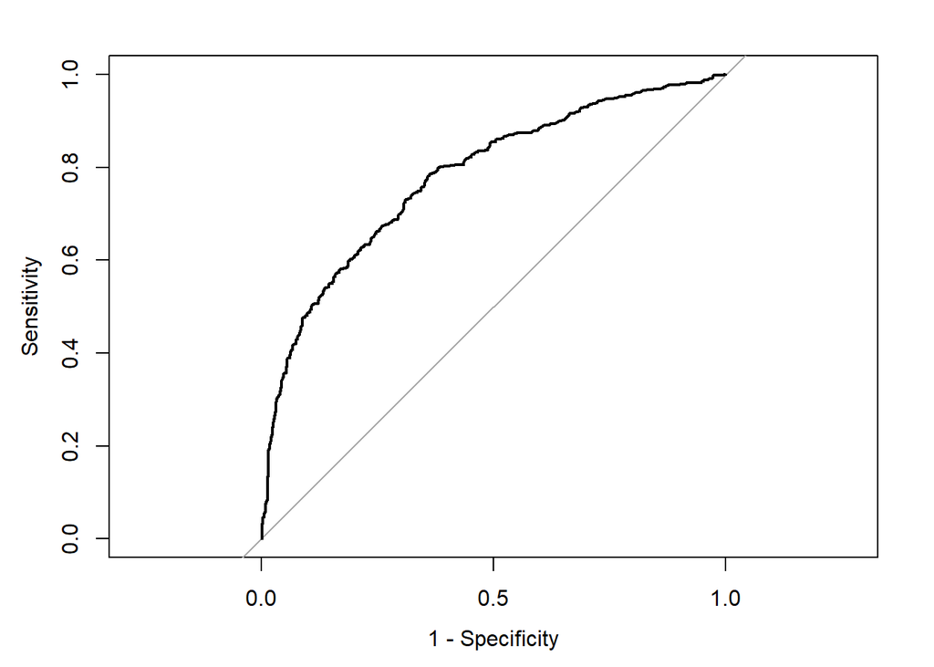

```
##
## Call:
## roc.default(response = df$quality, predictor = logistic$fitted.values,     plot = TRUE, legacy.axes = TRUE)
##
## Data: logistic$fitted.values in 744 controls (df$quality bad) < 855 cases (df$quality good).
## Area under the curve: 0.7792
```

```r
## NOTE: By default, roc() uses specificity on the x-axis and the values range
## from 1 to 0. This makes the graph look like what we would expect, but the
## x-axis itself might induce a headache. To use 1-specificity (i.e. the
## False Positive Rate) on the x-axis, set "legacy.axes" to TRUE.
roc(df$quality,logistic$fitted.values,plot=TRUE, legacy.axes=TRUE)
```

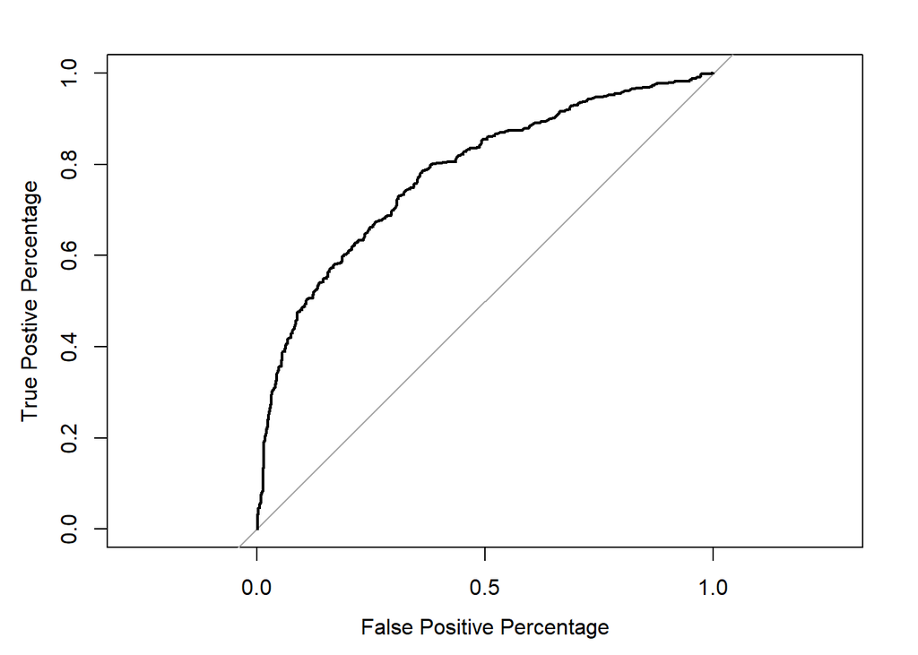

```
##
## Call:
## roc.default(response = df$quality, predictor = logistic$fitted.values,     plot = TRUE, legacy.axes = TRUE, xlab = "False Positive Percentage",     ylab = "True Postive Percentage")
##
## Data: logistic$fitted.values in 744 controls (df$quality bad) < 855 cases (df$quality good).
## Area under the curve: 0.7792
```

```r
roc(df$quality,logistic$fitted.values,plot=TRUE, legacy.axes=TRUE, xlab="False Positive Percentage", ylab="True Postive Percentage")
```

```r
roc(df$quality,logistic$fitted.values,plot=TRUE, legacy.axes=TRUE, xlab="False Positive Percentage", ylab="True Postive Percentage", col="#377eb8", lwd=4)
```

```
##
## Call:
## roc.default(response = df$quality, predictor = logistic$fitted.values,     plot = TRUE, legacy.axes = TRUE, xlab = "False Positive Percentage",     ylab = "True Postive Percentage", col = "#377eb8", lwd = 4)
##
## Data: logistic$fitted.values in 744 controls (df$quality bad) < 855 cases (df$quality good).
## Area under the curve: 0.7792
```

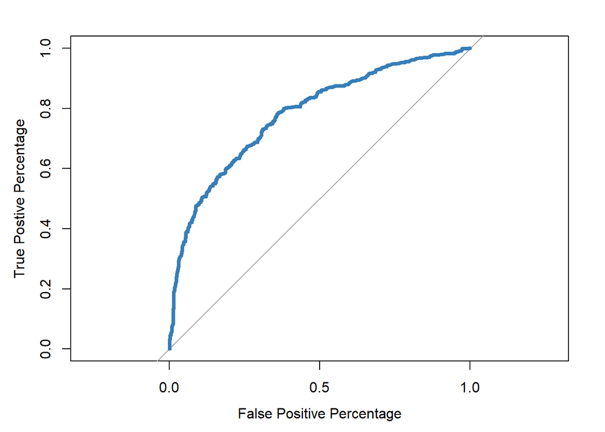

```
##
## Call:
## roc.default(response = df$quality, predictor = logistic$fitted.values,     plot = TRUE, legacy.axes = TRUE, xlab = "False Positive Percentage",     ylab = "True Postive Percentage", col = "#377eb8", lwd = 4)
##
## Data: logistic$fitted.values in 744 controls (df$quality bad) < 855 cases (df$quality good).
## Area under the curve: 0.7792
```

```r
roc(df$quality,logistic$fitted.values,plot=TRUE, legacy.axes=TRUE, xlab="False Positive Percentage", ylab="True Postive Percentage", col="#377eb8", lwd=4)
```

```r
## If we want to find out the optimal threshold we can store the
## data used to make the ROC graph in a variable...
roc.info <- roc(df$quality, logistic$fitted.values, legacy.axes=TRUE)
str(roc.info)
```

```
## List of 15
##  $ percent           : logi FALSE
##  $ sensitivities     : num [1:890] 1 1 1 1 1 ...
##  $ specificities     : num [1:890] 0 0.00134 0.00269 0.00403 0.00538 ...
##  $ thresholds        : num [1:890] -Inf 0.123 0.135 0.144 0.148 ...
##  $ direction         : chr "<"
##  $ cases             : Named num [1:855] 0.352 0.333 0.279 0.639 0.526 ...
##   ..- attr(*, "names")= chr [1:855] "4" "8" "9" "17" ...
##  $ controls          : Named num [1:744] 0.254 0.415 0.396 0.254 0.254 ...
##   ..- attr(*, "names")= chr [1:744] "1" "2" "3" "5" ...
##  $ fun.sesp          :function (thresholds, controls, cases, direction)
##  $ auc               : 'auc' num 0.779
##   ..- attr(*, "partial.auc")= logi FALSE
##   ..- attr(*, "percent")= logi FALSE
##   ..- attr(*, "roc")=List of 15
##   .. ..$ percent           : logi FALSE
##   .. ..$ sensitivities     : num [1:890] 1 1 1 1 1 ...
##   .. ..$ specificities     : num [1:890] 0 0.00134 0.00269 0.00403 0.00538 ...
##   .. ..$ thresholds        : num [1:890] -Inf 0.123 0.135 0.144 0.148 ...
##   .. ..$ direction         : chr "<"
##   .. ..$ cases             : Named num [1:855] 0.352 0.333 0.279 0.639 0.526 ...
##   .. .. ..- attr(*, "names")= chr [1:855] "4" "8" "9" "17" ...
##   .. ..$ controls          : Named num [1:744] 0.254 0.415 0.396 0.254 0.254 ...
##   .. .. ..- attr(*, "names")= chr [1:744] "1" "2" "3" "5" ...
##   .. ..$ fun.sesp          :function (thresholds, controls, cases, direction)
##   .. ..$ auc               : 'auc' num 0.779
##   .. .. ..- attr(*, "partial.auc")= logi FALSE
##   .. .. ..- attr(*, "percent")= logi FALSE
##   .. .. ..- attr(*, "roc")=List of 8
##   .. .. .. ..$ percent      : logi FALSE
##   .. .. .. ..$ sensitivities: num [1:890] 1 1 1 1 1 ...
##   .. .. .. ..$ specificities: num [1:890] 0 0.00134 0.00269 0.00403 0.00538 ...
##   .. .. .. ..$ thresholds   : num [1:890] -Inf 0.123 0.135 0.144 0.148 ...
##   .. .. .. ..$ direction    : chr "<"
##   .. .. .. ..$ cases        : Named num [1:855] 0.352 0.333 0.279 0.639 0.526 ...
##   .. .. .. .. ..- attr(*, "names")= chr [1:855] "4" "8" "9" "17" ...
##   .. .. .. ..$ controls     : Named num [1:744] 0.254 0.415 0.396 0.254 0.254 ...
##   .. .. .. .. ..- attr(*, "names")= chr [1:744] "1" "2" "3" "5" ...
##   .. .. .. ..$ fun.sesp     :function (thresholds, controls, cases, direction)
##   .. .. .. ..- attr(*, "class")= chr "roc"
##   .. ..$ call              : language roc.default(response = df$quality, predictor = logistic$fitted.values,      legacy.axes = TRUE)
##   .. ..$ original.predictor: Named num [1:1599] 0.254 0.415 0.396 0.352 0.254 ...
##   .. .. ..- attr(*, "names")= chr [1:1599] "1" "2" "3" "4" ...
##   .. ..$ original.response : Factor w/ 2 levels "bad","good": 1 1 1 2 1 1 1 2 2 1 ...
##   .. ..$ predictor         : Named num [1:1599] 0.254 0.415 0.396 0.352 0.254 ...
##   .. .. ..- attr(*, "names")= chr [1:1599] "1" "2" "3" "4" ...
##   .. ..$ response          : Factor w/ 2 levels "bad","good": 1 1 1 2 1 1 1 2 2 1 ...
##   .. ..$ levels            : chr [1:2] "bad" "good"
##   .. ..- attr(*, "class")= chr "roc"
##  $ call              : language roc.default(response = df$quality, predictor = logistic$fitted.values,      legacy.axes = TRUE)
##  $ original.predictor: Named num [1:1599] 0.254 0.415 0.396 0.352 0.254 ...
##   ..- attr(*, "names")= chr [1:1599] "1" "2" "3" "4" ...
##  $ original.response : Factor w/ 2 levels "bad","good": 1 1 1 2 1 1 1 2 2 1 ...
##  $ predictor         : Named num [1:1599] 0.254 0.415 0.396 0.352 0.254 ...
##   ..- attr(*, "names")= chr [1:1599] "1" "2" "3" "4" ...
##  $ response          : Factor w/ 2 levels "bad","good": 1 1 1 2 1 1 1 2 2 1 ...
##  $ levels            : chr [1:2] "bad" "good"
##  - attr(*, "class")= chr "roc"
```

```r
## tpp = true positive percentage
## fpp = false positive precentage
roc.df <- data.frame(tpp=roc.info$sensitivities*100, fpp=(1 - roc.info$specificities)*100,thresholds=roc.info$thresholds)
roc.df
```

```
##             tpp         fpp thresholds
## 1   100.0000000 100.0000000       -Inf
## 2   100.0000000  99.8655914  0.1228900
## 3   100.0000000  99.7311828  0.1351202
## 4   100.0000000  99.5967742  0.1443528
## 5   100.0000000  99.4623656  0.1477965
## 6    99.8830409  99.4623656  0.1518881
## 7    99.8830409  99.3279570  0.1553623
## 8    99.8830409  99.1935484  0.1584759
## 9    99.8830409  98.9247312  0.1602615
## 10   99.8830409  98.7903226  0.1620720
## 11   99.8830409  98.6559140  0.1650810
## 12   99.8830409  98.5215054  0.1669244
## 13   99.8830409  98.3870968  0.1673642
## 14   99.7660819  98.3870968  0.1694647
```

[output cut: 876 more lines]

```r
head(roc.df)
```

```
##         tpp       fpp thresholds
## 1 100.00000 100.00000       -Inf
## 2 100.00000  99.86559  0.1228900
## 3 100.00000  99.73118  0.1351202
## 4 100.00000  99.59677  0.1443528
## 5 100.00000  99.46237  0.1477965
## 6  99.88304  99.46237  0.1518881
```

```r
## head() will show us the values for the upper right-hand corner of the ROC graph, when the threshold is so low
## (negative infinity) that every single sample is called "obese".
## Thus TPP = 100% and FPP = 100%
tail(roc.df)
```

```
##           tpp       fpp thresholds
## 885 0.8187135 0.1344086  0.9845381
## 886 0.5847953 0.1344086  0.9850454
## 887 0.4678363 0.1344086  0.9859803
## 888 0.1169591 0.1344086  0.9872237
## 889 0.0000000 0.1344086  0.9915600
## 890 0.0000000 0.0000000        Inf
```

```r
## tail() will show us the values for the lower left-hand corner
## of the ROC graph, when the threshold is so high (infinity)
## that every single sample is called "not obese".
## Thus, TPP = 0% and FPP = 0%
## now let's look at the thresholds between TPP 60% and 80%
roc.df[roc.df$tpp > 60 & roc.df$tpp < 80,]
```

```
##          tpp      fpp thresholds
## 252 79.64912 38.03763  0.4133210
## 253 79.41520 38.03763  0.4144707
## 254 79.29825 37.90323  0.4167733
## 255 79.29825 37.76882  0.4184852
## 256 79.18129 37.76882  0.4190458
## 257 79.06433 37.63441  0.4198151
## 258 78.94737 37.36559  0.4203923
## 259 78.94737 37.23118  0.4215477
## 260 78.83041 37.09677  0.4232819
## 261 78.71345 37.09677  0.4250019
## 262 78.71345 36.96237  0.4261601
## 263 78.71345 36.82796  0.4265465
## 264 78.71345 36.69355  0.4271099
## 265 78.59649 36.69355  0.4282700
```

[output cut: 167 more lines]

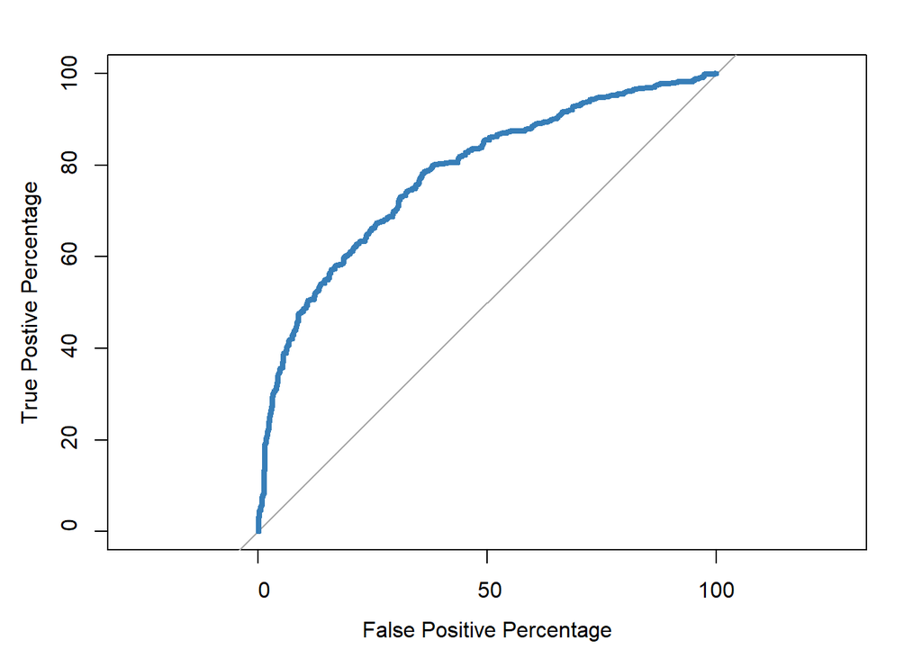

```
##
## Call:
## roc.default(response = df$quality, predictor = logistic$fitted.values,     percent = TRUE, plot = TRUE, legacy.axes = TRUE, xlab = "False Positive Percentage",     ylab = "True Postive Percentage", col = "#377eb8", lwd = 4)
##
## Data: logistic$fitted.values in 744 controls (df$quality bad) < 855 cases (df$quality good).
## Area under the curve: 77.92%
```

```r
roc(df$quality,logistic$fitted.values,plot=TRUE, legacy.axes=TRUE, xlab="False Positive Percentage", ylab="True Postive Percentage", col="#377eb8", lwd=4, percent=TRUE)
```

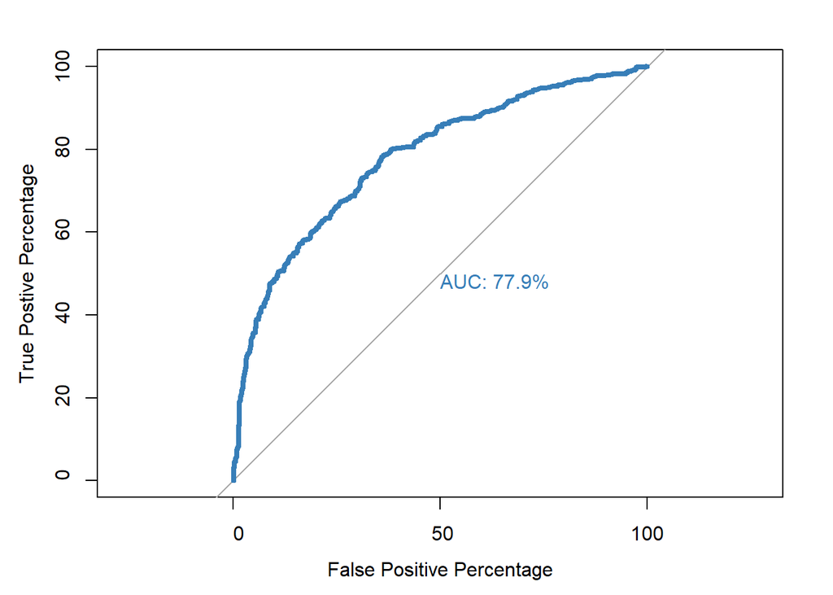

```
##
## Call:
## roc.default(response = df$quality, predictor = logistic$fitted.values,     percent = TRUE, plot = TRUE, legacy.axes = TRUE, xlab = "False Positive Percentage",     ylab = "True Postive Percentage", col = "#377eb8", lwd = 4,     print.auc = TRUE)
##
## Data: logistic$fitted.values in 744 controls (df$quality bad) < 855 cases (df$quality good).
## Area under the curve: 77.92%
```

```r
roc(df$quality,logistic$fitted.values,plot=TRUE, legacy.axes=TRUE, xlab="False Positive Percentage", ylab="True Postive Percentage", col="#377eb8", lwd=4, percent=TRUE, print.auc=TRUE)
```

```r
# Lets do two roc plots to understand which model is better
roc(df$quality, logistic_simple$fitted.values, plot=TRUE, legacy.axes=TRUE, percent=TRUE, xlab="False Positive Percentage", ylab="True Postive Percentage", col="#377eb8", lwd=4, print.auc=TRUE)
```

```
##
## Call:
## roc.default(response = df$quality, predictor = logistic_simple$fitted.values,     percent = TRUE, plot = TRUE, legacy.axes = TRUE, xlab = "False Positive Percentage",     ylab = "True Postive Percentage", col = "#377eb8", lwd = 4,     print.auc = TRUE)
##
## Data: logistic_simple$fitted.values in 744 controls (df$quality bad) < 855 cases (df$quality good).
## Area under the curve: 79.55%
```

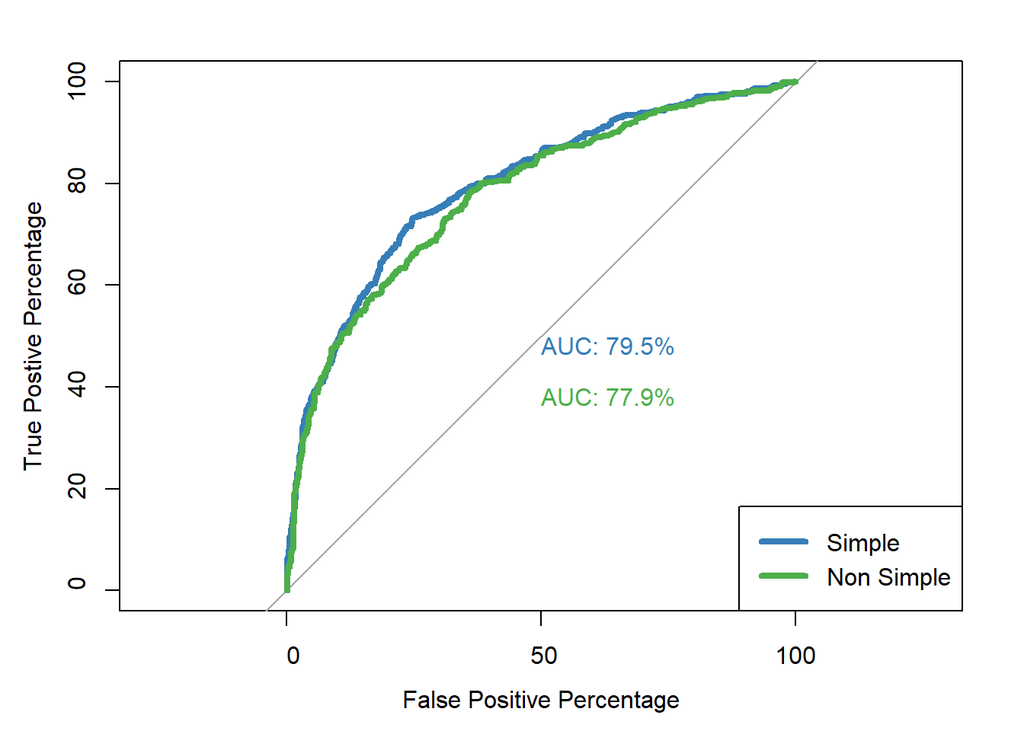

```r
# Lets add the other graph
plot.roc(df$quality, logistic$fitted.values, percent=TRUE, col="#4daf4a", lwd=4, print.auc=TRUE, add=TRUE, print.auc.y=40)
legend("bottomright", legend=c("Simple", "Non Simple"), col=c("#377eb8", "#4daf4a"), lwd=4)
```

[output not shown]